# Diagnostic Plots for linear regression model

Major assumptions of linear regression include

```
1. The relationship between the outcomes and the predictors is (approximately) linear.
2. The error term $\epsilon$ has zero mean.
3. The error term $\epsilon$ has constant variance.
4. The errors are uncorrelated.
5. The errors are normally distributed or we have an adequate sample size to rely on large sample theory.
```

```python
# sample model and plots
import pandas as pd
import numpy as np
import statsmodels.formula.api as smf
import matplotlib.pyplot as plt
%matplotlib inline

# read the data
data = pd.read_csv('http://www-bcf.usc.edu/~gareth/ISL/Advertising.csv', index_col=0)

# fitting the model
fit = smf.ols(formula='Sales ~ TV+Radio', data=data).fit()
print(fit.summary())
```

```
                            OLS Regression Results
==============================================================================
Dep. Variable:                  Sales   R-squared:                       0.897
Model:                            OLS   Adj. R-squared:                  0.896
Method:                 Least Squares   F-statistic:                     859.6
Date:                Wed, 31 Aug 2016   Prob (F-statistic):           4.83e-98
Time:                        22:00:10   Log-Likelihood:                -386.20
No. Observations:                 200   AIC:                             778.4
Df Residuals:                     197   BIC:                             788.3
Df Model:                           2
Covariance Type:            nonrobust
==============================================================================
                 coef    std err          t      P>|t|      [95.0% Conf. Int.]
------------------------------------------------------------------------------
Intercept      2.9211      0.294      9.919      0.000         2.340     3.502
TV             0.0458      0.001     32.909      0.000         0.043     0.048
Radio          0.1880      0.008     23.382      0.000         0.172     0.204
==============================================================================
Omnibus:                       60.022   Durbin-Watson:                   2.081
Prob(Omnibus):                  0.000   Jarque-Bera (JB):              148.679
Skew:                          -1.323   Prob(JB):                     5.19e-33
Kurtosis:                       6.292   Cond. No.                         425.
==============================================================================

Warnings:
[1] Standard Errors assume that the covariance matrix of the errors is correctly specified.
```

## Normality check based on the residuals

If the normal assumption is satisfied, the residuals should stay on a straightline on the normal quantile quantile plot. If there is obvious deviation from the straightline, then the normality assumption should be reconsidered.

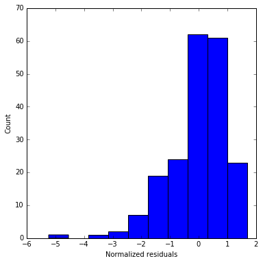

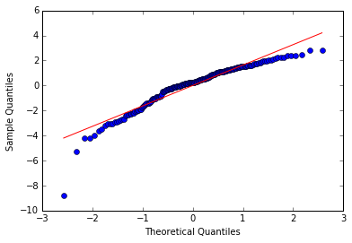

```python
# get the residuals of the fitted model
res = fit.resid

import statsmodels.api as sm
import scipy.stats as stats

f1 = plt.figure(figsize=(6,6))
f1 = plt.hist(fit.resid_pearson)
f1 = plt.ylabel('Count')
f1 = plt.xlabel('Normalized residuals')

fig = plt.figure(figsize=(6,6))
fig = sm.qqplot(res, stats.distributions.norm, line='r')
# plt.show()
```

## Scatter Plot for the residuals

There are generally two categories of scatter plots. The residuals vs fitted values and the residuals versus different predictors. The following functions provide several useful plots for each predictors.

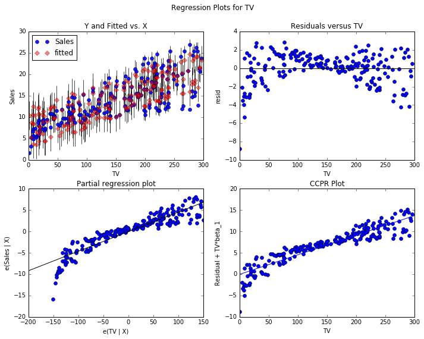

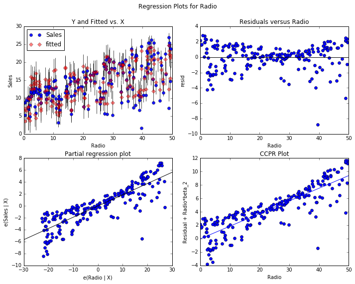

```python
# regression exog plot
fig = plt.figure(figsize=(10,8))
fig = sm.graphics.plot_regress_exog(fit, "TV", fig=fig)

fig1 = plt.figure(figsize=(10,8))
fig1 = sm.graphics.plot_regress_exog(fit, "Radio", fig=fig1)
```

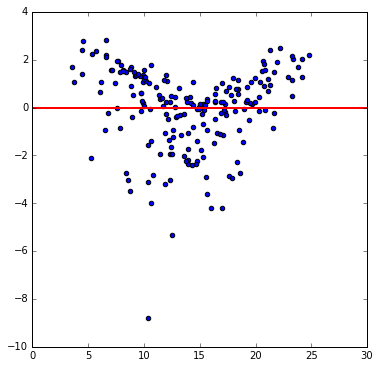

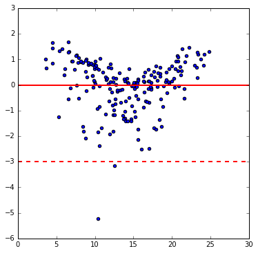

```python
# plot the residuals vs fitted values
fig = plt.figure(figsize=(6,6))
plt.scatter(fit.fittedvalues, fit.resid)
plt.axhline(y=0, linewidth=2, color = 'r')

fig = plt.figure(figsize=(6,6))
plt.scatter(fit.fittedvalues, fit.resid_pearson)
plt.axhline(y=0, linewidth=2, color = 'r')
plt.axhline(y=3, linestyle='dashed', linewidth=2, color = 'r')
plt.axhline(y=-3, linestyle='dashed', linewidth=2, color = 'r')
```

# Influential Points and Outliers

Influence plots show the (externally) studentized residuals vs. the leverage of each observation as measured by the hat matrix.

Externally studentized residuals are residuals that are scaled by their standard deviation where

$$var(\hat{\epsilon}_i)=\hat{\sigma}^2_i(1-h_{ii})$$

with

$$\hat{\sigma}^2_i=\frac{1}{n -p- 1}\sum_{j=1}^{n}(y_j-\hat y_{-i})^2\;\forall \; j \neq i$$

$n$ is the number of observations and $p$ is the number of regressors. $h_{ii}$ is the $i$-th diagonal element of the hat matrix

$$H=X(X^{\prime}X)^{-1}X^{\prime}$$

The influence of each point can be visualized by the criterion keyword argument. Options are Cook's distance and DFFITS, two measures of influence.

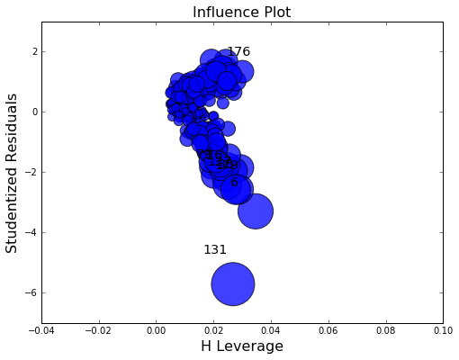

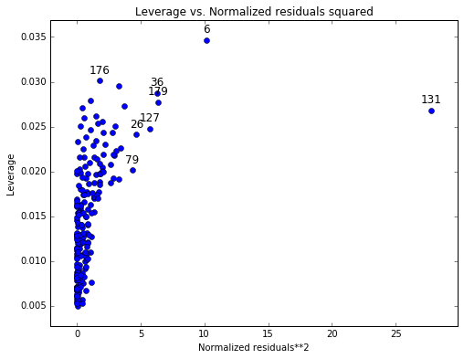

```python
fig, ax = plt.subplots(figsize=(8,6))
fig = sm.graphics.influence_plot(fit, ax=ax, criterion="cooks")

fig1, ax = plt.subplots(figsize=(8,6))
fig1 = sm.graphics.plot_leverage_resid2(fit, ax=ax)
```

As can be seen from the graph, the leverage of all points are similar. There is one point, which appears to have higher influence (with larger circled area). In general, there is no alarming points.

## Cook's distance

The cook's distance indicates the influence of each data points. It depends on the leverage of the point as well as the deviation from the model supported by other points.

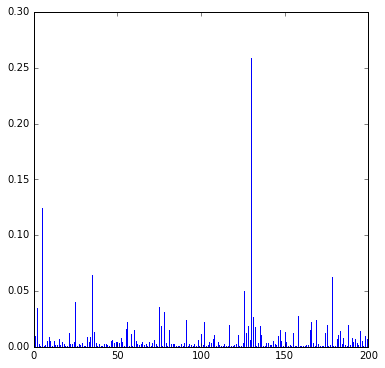

```python
# get the influence measure
influence = fit.get_influence()
#c is the distance and p is p-value
(c, p) = influence.cooks_distance
fig = plt.figure(figsize=(6,6))
fig = plt.stem(np.arange(len(c)), c, markerfmt=",")
```

## Partial regression plots

Since we are doing multivariate regressions, we cannot just look at individual bivariate plots to discern relationships. Instead, we want to look at the relationship of the dependent variable and independent variables conditional on the other independent variables. We can do this through using partial regression plots, otherwise known as **added variable plots**.

In a partial regression plot, to discern the relationship between the response variable and the $k$th variabe, we compute the residuals by regressing the response variable versus the independent variables excluding $X_k$. We can denote this by $X_{\sim k}$. We then compute the residuals by regressing $X_k$ on $X_{\sim k}$. The partial regression plot is the plot of the former versus the latter residuals.

The notable points of this plot are that the fitted line has slope $\beta_k$ and intercept zero. The residuals of this plot are the same as those of the least squares fit of the original model with full $X$. You can discern the effects of the individual data values on the estimation of a coefficient easily. If obs_labels is True, then these points are annotated with their observation label. You can also see the violation of underlying assumptions such as homooskedasticity and linearity.

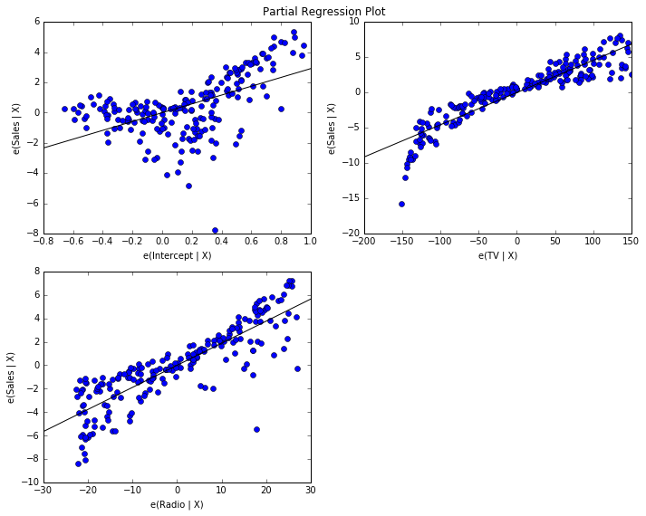

```python
import statsmodels.api as sm
fig  = plt.figure(figsize=(10,8))
fig = sm.graphics.plot_partregress_grid(fit, fig=fig)
```

The plot_regress_exog function is a convenience function that gives a 2x2 plot containing the dependent variable and fitted values with confidence intervals vs. the independent variable chosen, the residuals of the model vs. the chosen independent variable, a partial regression plot, and a CCPR plot. This function can be used for quickly checking modeling assumptions with respect to a single regressor.

## Variance inflation factor

This is to detect collinearity in the predictors. If a predictor is (nearly) a linear combination of others, the VIF is high, and some predictors should be removed from the model to improve the accuracy of the parameter estimation.

```python
import statsmodels.stats as sms
print(sms.outliers_influence.variance_inflation_factor(fit.model.exog, 0))
print(sms.outliers_influence.variance_inflation_factor(fit.model.exog, 1))
print(sms.outliers_influence.variance_inflation_factor(fit.model.exog, 2))
# sm.

inf = sms.outliers_influence.OLSInfluence(fit)
inf.summary_table()
```

```
6.13547593725
1.00301304084
1.00301304084
```

| obs | endog | fitted | Cook's | student. | hat diag | dffits | ext.stud. | dffits |
| --- | --- | --- | --- | --- | --- | --- | --- | --- |
|  |  | value | d | residual |  | internal | residual |  |
| 0.0 | 22.1 | 20.5554646334 | 0.00405821834634 | 0.925132717386 | 0.014025369925 | 0.110338819275 | 0.924792754679 | 0.11029827257 |
| 1.0 | 10.4 | 12.3453622906 | 0.00870544359165 | -1.16803806996 | 0.0187829265808 | -0.16160547879 | -1.16912512483 | -0.161755879729 |
| 2.0 | 9.3 | 12.337017734 | 0.0340855181795 | -1.83354988769 | 0.0295184122625 | -0.319775787918 | -1.84469837856 | -0.321720113226 |
| 3.0 | 18.5 | 17.6171159596 | 0.00117012265495 | 0.52839159735 | 0.0124169367949 | 0.0592483583304 | 0.527422672339 | 0.05913971312 |
| 4.0 | 12.9 | 13.2239081302 | 0.000119966545955 | -0.193569397869 | 0.00951385257688 | -0.0189710210022 | -0.193095844072 | -0.0189246097454 |
| 5.0 | 7.2 | 12.5120844855 | 0.123721412306 | -3.21560011383 | 0.0346518188654 | -0.609232498245 | -3.2950691882 | -0.62428883019 |
| 6.0 | 11.8 | 11.7182124139 | 1.04689918099e-05 | 0.0489612974814 | 0.0129320486482 | 0.00560419266528 | 0.048837169268 | 0.00558998474068 |
| 7.0 | 13.2 | 12.1055155293 | 0.000822602073971 | 0.652833441882 | 0.0057570340122 | 0.0496770190522 | 0.651879919262 | 0.0496044612475 |
| 8.0 | 4.8 | 3.70937919818 | 0.0040120231516 | 0.657618160677 | 0.0270779107666 | 0.109709021757 | 0.656668122541 | 0.10955052894 |
| 9.0 | 10.6 | 12.5516969588 | 0.00796887353717 | -1.17086144501 | 0.0171395353698 | -0.154617659443 | -1.17197090733 | -0.154764169065 |
| 10.0 | 8.6 | 7.03585970498 | 0.00471809451146 | 0.937739419064 | 0.0158412232987 | 0.118971776209 | 0.937450946701 | 0.118935177482 |
| 11.0 | 17.4 | 17.2565201535 | 2.00367338337e-05 | 0.085684169809 | 0.00812092919323 | 0.00775307690541 | 0.0854680132354 | 0.0077335181171 |
| 12.0 | 9.2 | 10.6086618662 | 0.00467540127005 | -0.845980537861 | 0.019221632923 | -0.118432275205 | -0.84536761637 | -0.118346469818 |
| 13.0 | 9.7 | 8.81095050707 | 0.00114105669884 | 0.531956417584 | 0.0119523761556 | 0.0585078635443 | 0.530986057091 | 0.0584011372836 |
| 14.0 | 19.0 | 18.4446677303 | 0.000337425882532 | 0.331802350717 | 0.00911099357081 | 0.0318163110306 | 0.331051657837 | 0.0317443275799 |
| 15.0 | 22.4 | 20.8289153929 | 0.00597903298916 | 0.943774168362 | 0.0197404529082 | 0.13392945519 | 0.943511152381 | 0.133892131021 |
| 16.0 | 12.5 | 12.9038650706 | 0.00027326177724 | -0.241878316032 | 0.0138185696271 | -0.0286318936105 | -0.241299463881 | -0.0285633730689 |
| 17.0 | 24.4 | 23.241076256 | 0.00372827527086 | 0.697163027509 | 0.0224946719398 | 0.105758336847 | 0.696250748595 | 0.105619945829 |
| 18.0 | 11.3 | 9.94121476312 | 0.00204583051328 | 0.81189960376 | 0.00922489292893 | 0.0783421440851 | 0.811194628029 | 0.0782741192824 |
| 19.0 | 14.6 | 14.153846193 | 0.000118756764546 | 0.266019901771 | 0.00500922349712 | 0.0188751236722 | 0.265391536772 | 0.0188305387859 |
| 20.0 | 18.0 | 18.1213916079 | 1.55533062808e-05 | -0.0725180113835 | 0.00879459547539 | -0.00683080660262 | -0.0723346868329 | -0.00681353841604 |
| 21.0 | 12.5 | 14.7420635732 | 0.011598887865 | -1.34622208558 | 0.0188384302549 | -0.186538638343 | -1.34902046783 | -0.186926394882 |
| 22.0 | 5.6 | 6.514171675 | 0.00184593559791 | -0.548687211149 | 0.0180622594642 | -0.0744164416894 | -0.547711501756 | -0.0742841097894 |
| 23.0 | 15.5 | 16.5440266299 | 0.00140043547335 | -0.624279379501 | 0.0106652160198 | -0.06481748545 | -0.623309749714 | -0.0647168110297 |
| 24.0 | 9.7 | 8.14035214862 | 0.00356184243725 | 0.933282948787 | 0.0121191969211 | 0.103370824277 | 0.932976014614 | 0.103336828115 |
| 25.0 | 12.0 | 15.6080205956 | 0.0388468984586 | -2.17223121451 | 0.0241029126397 | -0.34138057264 | -2.19313534929 | -0.344665796356 |
| 26.0 | 15.0 | 14.9676938303 | 7.29128425558e-07 | 0.0192708024135 | 0.00585565034358 | 0.0014789811617 | 0.0192218476376 | 0.0014752240171 |
| 27.0 | 15.9 | 17.0463346027 | 0.00193267953506 | -0.685977189104 | 0.0121714779242 | -0.0761448527818 | -0.685052580887 | -0.0760422194033 |
| 28.0 | 18.9 | 19.399541451 | 0.000369369034319 | -0.2989417497 | 0.0122477586111 | -0.0332882427136 | -0.298249704963 | -0.0332111810346 |

[output cut: 171 more lines]